# HW05: Data Visulaization

#### Plot 6

Is not here.

#### Plot 7

Data is already loaded from last plots, so here is plot 7.

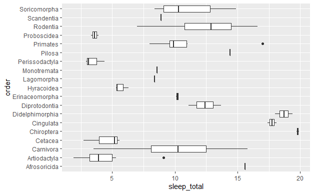

```r
ggplot(data = msleep) +
  geom_boxplot(mapping = aes(x = order, y = sleep_total)) +
  coord_flip()
```

There are not any patterns really, some have large ranges and others hardly at all. They are also all over the place.

#### Plot 8

Dataset is already loaded so this is Plot 8.

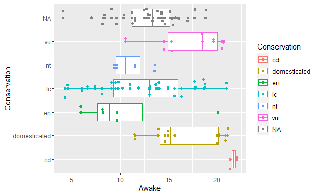

#### Plot 9

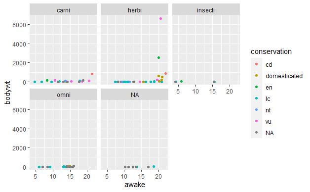

carni and herbi are the only two with individuals with a body weight more than 500 and they have a large varying amount on awake. The otehr three are more together in awake rather than all over.

#### Plot 10

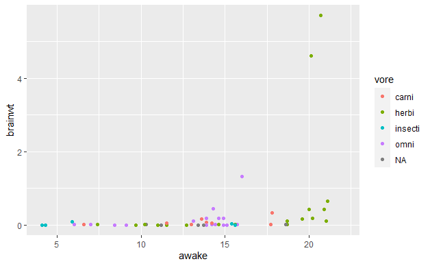

It appears as those who have a larger brain weight are higher in awake time.the herbi and omni have higher brain weight than the other vores.